# Tesla Tweets

### Alex Bzdel, Gina Catellier, Zach Galante

```python
! pip install pymongo
```

```python
from pymongo import MongoClient
import pandas as pd
import numpy as np
import matplotlib.pyplot as plt
%matplotlib inline
import seaborn as sns
```

```python
mongo_host = 'mongodb://localhost:27017/tweets'

def connect_db():
    client = MongoClient("localhost", 27017)
    return client

client = connect_db()
db = client.tesla
```

## Question 1 : What are the top 10 hashtags used in tweets about Tesla?

```python
# display top hashtags

def topNHashtags(n):

    pipeline=[
        {"$addFields": {"textArray": {"$split": ["$text", " "]}}},
        {"$unwind": "$textArray"},
        {"$addFields": {"textArray": {"$toLower": "$textArray"}}},
        {"$match": {"textArray": {"$regex":"^#"}}},
        {"$match": {"textArray": {"$nin": ["#tesla\n"]}}},
        {"$group": {
            "_id": "$textArray",
            "frequency": {"$sum":1}
        }},
        {"$sort": {"frequency":-1}},
        {"$limit":n}
    ]

    result_list = []
    result = db.tesla_tweets.aggregate(pipeline)

    for res in result:
        result_list.append(res)

    return result_list
```

```python
# top 10 hashtags
result_list1 = topNHashtags(10)
result_list1
```

```
[{'_id': '#tesla', 'frequency': 765},
 {'_id': '#bitcoin', 'frequency': 599},
 {'_id': '#dogecoin', 'frequency': 93},
 {'_id': '#ineedatesla', 'frequency': 75},
 {'_id': '#concours', 'frequency': 69},
 {'_id': '#elonmusk', 'frequency': 68},
 {'_id': '#options', 'frequency': 67},
 {'_id': '#cybertruck', 'frequency': 58},
 {'_id': '#btc', 'frequency': 52},
 {'_id': '#doge', 'frequency': 49}]
```

```python
result_1 = pd.DataFrame(list(result_list1))
result_1.head()
```

|  | _id | frequency |
| --- | --- | --- |
| 0 | #tesla | 765 |
| 1 | #bitcoin | 599 |
| 2 | #dogecoin | 93 |
| 3 | #ineedatesla | 75 |
| 4 | #concours | 69 |

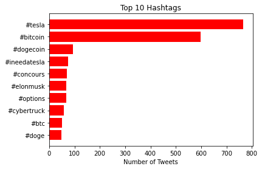

```python
result_1 = result_1.sort_values('frequency',ascending=True)

plt.rcParams["figure.figsize"] = (6,4)

x = result_1["_id"]
y = result_1["frequency"]

plt.barh(x,y,color='red')
plt.xlabel("Number of Tweets")
plt.title("Top 10 Hashtags")
```

## Question 2 : What were the top 10 tweets based on the user having the highest follower count?

```python
pipeline = [
    {"$sort": {"user.followers_count": -1}},
    {"$limit":10},
    {"$project": {
        "_id":0,
        "text":1,
        "user.followers_count": 1,
    }
    }

]

result = db.tesla_tweets.aggregate(pipeline)

for res in result:
    print(res)
```

```
{'text': 'Whether out of hope, envy or morbid curiosity, China cannot get enough of Elon Musk. The Tesla boss and digital pra… https://t.co/X7TaqbDMFI', 'user': {'followers_count': 49597595}}
{'text': "Firefighters responding to fire at Tesla's Fremont factory: KTVU Fox 2 https://t.co/S6zPoGAwP0 https://t.co/dPojBZZip7", 'user': {'followers_count': 23223780}}
{'text': 'Penasaran artikel mana saja yang mampu menarik perhatian pencinta otomotif kemarin? Simak ulasannya: https://t.co/bJCYfcrizF', 'user': {'followers_count': 16766720}}
{'text': 'Air Jordan 1 "Tesla" ini didominasi warna hitam, outsole merah, serta logo Tesla pada toebox. https://t.co/XL0G7tOSyY', 'user': {'followers_count': 8098963}}
{'text': 'RT @NathanBomey: Are we seeing the beginning of the end of the gas car? Electric vehicles are gaining momentum after many underwhelming yea…', 'user': {'followers_count': 4315972}}
{'text': 'Stocks making the biggest moves midday: GE, Nio, Tesla, Bumble, Oracle &amp; more https://t.co/sb73AlJCyB', 'user': {'followers_count': 4031312}}
{'text': "New for subscribers: Here are Thursday's biggest analyst calls of the day: Tesla, Costco, GE, Nio, Exxon &amp; more. Ch… https://t.co/PwyDqESyji", 'user': {'followers_count': 4031035}}
{'text': 'Firefighters responded to a small fire at Tesla’s factory in Fremont, Calif., on Thursday afternoon.\nhttps://t.co/B9cuUYkTi0', 'user': {'followers_count': 3974821}}
{'text': 'Tesla Roars Back and Wall Street Goes for the Ride https://t.co/vyHbsc97Ti', 'user': {'followers_count': 3542448}}
{'text': 'RT @RTultimahora: ÚLTIMA HORA\n\nVIDEO: Se produce un incendio en una fábrica de Tesla en California https://t.co/SWUQzBI2zO https://t.co/ykO…', 'user': {'followers_count': 3513405}}
```

## Question 3 : What are the top 15 words used in tweets about Tesla? (ignoring stop words)

```python
# display top 15 words in the tweet text (not counting stop words)

from wordcloud import WordCloud, STOPWORDS
stopwords = set(STOPWORDS)

def tweetText():
    pipeline = [{"$addFields": {'tweetText': {'$split':['$text', " "]}}},
    {'$unwind': '$tweetText'},
    {"$match": {"tweetText": {"$nin": ["RT", "a", "the", "to", "", "and", "of", "is", "in", "you", "I", "my", "for",
                                      "be", "on", "that", "has", "your", "was", "at", "by", "from", "this", "de", "with",
                                      "have", "like", "So", "are", "it", "will", "if", "The", "now", "get", "Here", "could",
                                      "an"]}}},
    {'$group': {
            '_id': {"word": "$tweetText"},
            'count': {"$sum" : 1}
    }},
    {'$sort': {'count' : -1}},
    {'$limit': 15}
    ]


    result_list = []
    result = db.tesla_tweets.aggregate(pipeline)

    for res in result:
        result_list.append(res)

    return result_list
```

```python
top_tweets = tweetText()
top_tweets
```

```
[{'_id': {'word': 'Tesla'}, 'count': 9485},
 {'_id': {'word': '@elonmusk'}, 'count': 2732},
 {'_id': {'word': '@Tesla'}, 'count': 1553},
 {'_id': {'word': 'car'}, 'count': 1315},
 {'_id': {'word': 'Model'}, 'count': 1013},
 {'_id': {'word': 'Elon'}, 'count': 824},
 {'_id': {'word': '@issk_wanko:'}, 'count': 806},
 {'_id': {'word': 'テスラのぶーぶー、ガチで雨を想定してない説あるから好き'}, 'count': 806},
 {'_id': {'word': '@DraperYounce:'}, 'count': 802},
 {'_id': {'word': 'tesla'}, 'count': 752},
 {'_id': {'word': 'Thank'}, 'count': 738},
 {'_id': {'word': 'part'}, 'count': 707},
 {'_id': {'word': 'huge'}, 'count': 695},
 {'_id': {'word': 'made'}, 'count': 688},
 {'_id': {'word': 'life.'}, 'count': 679}]
```

```python
top_tweets = list(top_tweets)
text_df = pd.DataFrame(top_tweets)
text_df
```

|  | _id | count |
| --- | --- | --- |
| 0 | {'word': 'Tesla'} | 9485 |
| 1 | {'word': '@elonmusk'} | 2732 |
| 2 | {'word': '@Tesla'} | 1553 |
| 3 | {'word': 'car'} | 1315 |
| 4 | {'word': 'Model'} | 1013 |
| 5 | {'word': 'Elon'} | 824 |
| 6 | {'word': '@issk_wanko:'} | 806 |
| 7 | {'word': 'テスラのぶーぶー、ガチで雨を想定してない説あるから好き'} | 806 |
| 8 | {'word': '@DraperYounce:'} | 802 |
| 9 | {'word': 'tesla'} | 752 |
| 10 | {'word': 'Thank'} | 738 |
| 11 | {'word': 'part'} | 707 |
| 12 | {'word': 'huge'} | 695 |
| 13 | {'word': 'made'} | 688 |
| 14 | {'word': 'life.'} | 679 |

```python
text_df2 = text_df
text_df2 = pd.DataFrame(text_df2._id.tolist(), index= text_df2.index)
text_df2
```

|  | word |
| --- | --- |
| 0 | Tesla |
| 1 | @elonmusk |
| 2 | @Tesla |
| 3 | car |
| 4 | Model |
| 5 | Elon |
| 6 | @issk_wanko: |
| 7 | テスラのぶーぶー、ガチで雨を想定してない説あるから好き |
| 8 | @DraperYounce: |
| 9 | tesla |
| 10 | Thank |
| 11 | part |
| 12 | huge |
| 13 | made |
| 14 | life. |

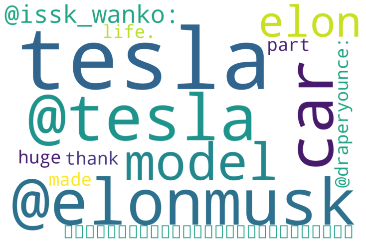

```python
from wordcloud import WordCloud

word_counts = {}
for text in text_df2['word']:
    text = str(text).lower()
    for word in text.split():
        word_counts[word] = word_counts.get(word, 0) + 1

%matplotlib inline
wordcloud = WordCloud(stopwords=stopwords, width = 1500, height = 1000,
                background_color ='white',
                min_font_size = 10).generate_from_frequencies(word_counts)

plt.figure(figsize = (10, 10), facecolor = None)
plt.imshow(wordcloud, interpolation='bilinear')
plt.axis("off")
plt.tight_layout(pad = 0)
plt.show()
```

```python
pipeline = [
    {"$sort": {"user.followers_count": -1}},
    {"$limit":10},
    {"$project": {
        "_id":0,
        "text":1,
        "user.followers_count": 1,
    }
    }

]

result = db.tesla_tweets.aggregate(pipeline)

for res in result:
    print(res)
```

```
{'text': 'Whether out of hope, envy or morbid curiosity, China cannot get enough of Elon Musk. The Tesla boss and digital pra… https://t.co/X7TaqbDMFI', 'user': {'followers_count': 49597595}}
{'text': "Firefighters responding to fire at Tesla's Fremont factory: KTVU Fox 2 https://t.co/S6zPoGAwP0 https://t.co/dPojBZZip7", 'user': {'followers_count': 23223780}}
{'text': 'Penasaran artikel mana saja yang mampu menarik perhatian pencinta otomotif kemarin? Simak ulasannya: https://t.co/bJCYfcrizF', 'user': {'followers_count': 16766720}}
{'text': 'Air Jordan 1 "Tesla" ini didominasi warna hitam, outsole merah, serta logo Tesla pada toebox. https://t.co/XL0G7tOSyY', 'user': {'followers_count': 8098963}}
{'text': 'RT @NathanBomey: Are we seeing the beginning of the end of the gas car? Electric vehicles are gaining momentum after many underwhelming yea…', 'user': {'followers_count': 4315972}}
{'text': 'Stocks making the biggest moves midday: GE, Nio, Tesla, Bumble, Oracle &amp; more https://t.co/sb73AlJCyB', 'user': {'followers_count': 4031312}}
{'text': "New for subscribers: Here are Thursday's biggest analyst calls of the day: Tesla, Costco, GE, Nio, Exxon &amp; more. Ch… https://t.co/PwyDqESyji", 'user': {'followers_count': 4031035}}
{'text': 'Firefighters responded to a small fire at Tesla’s factory in Fremont, Calif., on Thursday afternoon.\nhttps://t.co/B9cuUYkTi0', 'user': {'followers_count': 3974821}}
{'text': 'Tesla Roars Back and Wall Street Goes for the Ride https://t.co/vyHbsc97Ti', 'user': {'followers_count': 3542448}}
{'text': 'RT @RTultimahora: ÚLTIMA HORA\n\nVIDEO: Se produce un incendio en una fábrica de Tesla en California https://t.co/SWUQzBI2zO https://t.co/ykO…', 'user': {'followers_count': 3513405}}
```

## Question 5 : How many tweets are talking about Tesla as a stock vs. Tesla's tech or otherwise?

```python
pipeline = [
  #  {"$match": {"text": { "$not": "/RT/i"}}},

    {"$match":
    {"$or":
         [{"text": {"$regex" : ".*crypto.*"}},
         {"text": {"$regex" : ".*revenue.*"}},
         {"text": {"$regex" : ".*$TSLA.*"}},
         {"text": {"$regex" : ".*trade.*"}},
         {"text": {"$regex" : ".*invest.*"}},
         {"text": {"$regex" : ".*stock.*"}},
         {"text": {"$regex" : ".*bitcoin.*"}},
         {"text": {"$regex" : ".*btc.*"}},
         {"text": {"$regex" : ".*doge.*"}},
         {"text": {"$regex" : ".*DD.*"}}]

    }},
    {"$group": {
        "_id": "$text",
        "count": {"$sum":1}}},
    {"$count": "count"}

]

result = db.tesla_tweets.aggregate(pipeline)

invest_tweets = []

for res in result:
    print(res)
    invest_tweets.append(res)
```

```
{'count': 1023}
```

```python
# opposite of above query - for visualization purposes

pipeline = [
    {"$match":
    {"$or":
         [{"text": {"$not": {"$regex" : ".*crypto.*"}}},
         {"text": {"$not": {"$regex" : ".*revenue.*"}}},
         {"text": {"$not": {"$regex" : ".*$TSLA.*"}}},
         {"text": {"$not": {"$regex" : ".*trade.*"}}},
         {"text": {"$not": {"$regex" : ".*invest.*"}}},
         {"text": {"$not": {"$regex" : ".*stock.*"}}},
          {"text": {"$not": {"$regex" : ".*bitcoin.*"}}},
          {"text": {"$not": {"$regex" : ".*btc.*"}}},
          {"text": {"$not": {"$regex" : ".*doge.*"}}},
          {"text": {"$not": {"$regex" : ".*DD.*"}}}


         ]

    }},
    {"$group": {
        "_id": "$text",
        "count": {"$sum":1}}},
    {"$count": "count"}

]

result = db.tesla_tweets.aggregate(pipeline)

non_invest_tweets = []

for res in result:
    print(res)
    non_invest_tweets.append(res)
```

```
{'count': 14201}
```

```python
total_tweets = invest_tweets + non_invest_tweets
```

```python
result_df = pd.DataFrame(list(total_tweets), index=["invest_tweets", "non_invest_tweets"])
result_df = result_df.rename(columns={0: "invest_tweets", 1: "non_invest_tweets"})
result_df
```

|  | count |
| --- | --- |
| invest_tweets | 1023 |
| non_invest_tweets | 14201 |

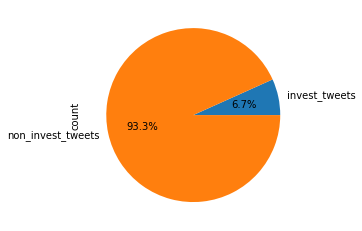

```python
result_df.plot(kind='pie', y='count', autopct='%1.1f%%', legend=False)
```

## Question 6 : What is the average number of followers for the top 10 users determined by favorites count?

```python
# display average followers for top users by favorites count

def topNFollowers(n):

    pipeline= [
        {"$group": {
            "_id" : "$user.screen_name",
            "followers" : {"$avg": "$user.followers_count"},
            "favorites" : {"$avg" : "$user.favourites_count"}
        }},
        {"$sort": {"favorites":-1}},
        {"$limit":n},
        {"$sort": {"followers":-1}},
    ]

    result_list = []
    result = db.tesla_tweets.aggregate(pipeline)

    for res in result:
        result_list.append(res)

    return result_list
```

```python
# top 10 favorites & followers
result_list6 = topNFollowers(10)
result_list6
```

```
[{'_id': 'paoloigna1', 'followers': 90332.25, 'favorites': 1211010.5},
 {'_id': 'littlebytesnews', 'followers': 20941.0, 'favorites': 1323143.0},
 {'_id': 'ramski67', 'followers': 13097.0, 'favorites': 913925.5},
 {'_id': 'takecchismt', 'followers': 6561.0, 'favorites': 1047977.0},
 {'_id': 'moai501', 'followers': 3104.0, 'favorites': 1261814.5},
 {'_id': '8492Squadron', 'followers': 3005.0, 'favorites': 2314586.0},
 {'_id': 'masataka_2007', 'followers': 2018.5, 'favorites': 1350622.0},
 {'_id': 'noisequeen', 'followers': 1573.0, 'favorites': 930849.0},
 {'_id': 'neko_mimisky', 'followers': 968.0, 'favorites': 999492.0},
 {'_id': 'Gojira007X', 'followers': 931.0, 'favorites': 1138755.0}]
```

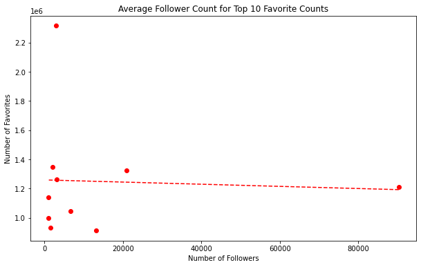

```python
result_6 = pd.DataFrame(list(result_list6))
x = result_6['followers']
y = result_6['favorites']

plt.rcParams["figure.figsize"] = (10,6)

plt.plot(x, y, 'o', color='red')
plt.xlabel("Number of Followers")
plt.ylabel("Number of Favorites")
plt.title("Average Follower Count for Top 10 Favorite Counts")

z = np.polyfit(x, y, 1)
p = np.poly1d(z)
plt.plot(x,p(x),"r--")
```

```python
pipeline = [
    {"$sort": {"user.followers_count": -1}},
    {"$limit":10},
    {"$group": {
        "_id": "null",
        "avgAccountFavs": {"$avg": "$user.favourites_count"},
        "minAccountFavs": {"$min": "$user.favourites_count"},
        "maxAccountFavs": {"$max": "$user.favourites_count"},
        "avgAccountFollowers": {"$avg": "$user.followers_count"}}},

    {"$project": {
        "_id":0,
        "avgAccountFavs":1,
        "minAccountFavs":1,
        "maxAccountFavs":1,
        "avgAccountFollowers":1
    }
    }
    ]

result = db.tesla_tweets.aggregate(pipeline)

reslist = []

for res in result:
    print(res)
    reslist.append(res)
```

```
{'avgAccountFavs': 2782.2, 'minAccountFavs': 129, 'maxAccountFavs': 18368, 'avgAccountFollowers': 12109605.1}
```

```python
resdf = pd.DataFrame(reslist).T
resdf.rename(columns={0: "count"})
```

|  | count |
| --- | --- |
| avgAccountFavs | 2782.2 |
| minAccountFavs | 129.0 |
| maxAccountFavs | 18368.0 |
| avgAccountFollowers | 12109605.1 |

## Question 8 : What is the highest number of favorites for tweets in the top 10 most used languages?

```python
# display highest amount of favorites per top languages

def topNLanguage(n):

    pipeline=[
        {"$group": {
            "_id": "$lang",
            "frequency" : {"$sum":1},
            "max_favorites" : {"$max" : "$user.favourites_count"}
        }},
        {"$sort": {"frequency":-1}},
        {"$limit":n},
        {"$sort": {"max_favorites":-1}},
    ]

    result_list = []
    result = db.tesla_tweets.aggregate(pipeline)

    for res in result:
        result_list.append(res)

    return result_list
```

```python
# top 10 languages
result_list9 = topNLanguage(10)
result_list9
```

```
[{'_id': 'ja', 'frequency': 1024, 'max_favorites': 2314586},
 {'_id': 'en', 'frequency': 17450, 'max_favorites': 1350664},
 {'_id': 'de', 'frequency': 353, 'max_favorites': 913945},
 {'_id': 'es', 'frequency': 1315, 'max_favorites': 741755},
 {'_id': 'und', 'frequency': 939, 'max_favorites': 440556},
 {'_id': 'fr', 'frequency': 374, 'max_favorites': 403017},
 {'_id': 'tr', 'frequency': 391, 'max_favorites': 379896},
 {'_id': 'nl', 'frequency': 132, 'max_favorites': 365183},
 {'_id': 'pt', 'frequency': 244, 'max_favorites': 290668},
 {'_id': 'in', 'frequency': 189, 'max_favorites': 243266}]
```

[output not shown]

[figure not shown]

```python
result_9 = pd.DataFrame(list(result_list9))

plt.rcParams["figure.figsize"] = (12,6)

sns.scatterplot(data = result_9, x = 'frequency', y='max_favorites', hue='_id', s=100)
plt.xlabel("Number of Highest Favorites")
plt.ylabel("Frequency of Langauge")
plt.title("Highest Count of Favorites  for Top 10 Languages")

z = np.polyfit(x, y, 1)
p = np.poly1d(z)
plt.plot(x,p(x),"r--")
```

```python
# display top hashtag for top 5 most popular languages

def topNHashtagLanguage(n):

    pipeline=[
        {"$addFields": {"textArray": {"$split": ["$text", " "]}}},
        {"$unwind": '$textArray'},
        {"$addFields": {"textArray": {"$toLower": "$textArray"}}},
        {"$match": {"textArray": {"$regex":"^#"}}},
        {"$match": {"textArray": {"$nin": ["#tesla\n", "#..."]}}},
        {"$group": {
        "_id": {"language": "$lang", "hashtag": "$textArray"},
        "frequency": {"$sum":1}
        }},
        {"$sort" : {'frequency' : -1}},
        {"$group": {
        "_id": "$_id.language",
        "total_hashtags": {"$push": {"hashtag": "$_id.hashtag", "frequency": "$frequency"}},
        "total_count" : {"$sum" : 1}
    }},
    {"$sort" : {'total_count' : -1}},
    {"$limit" : 5},
    {"$project": {
        "top5_hashtags": {"$slice": ["$total_hashtags", 0, 5]}}
    }
]


    result_list = []
    result = db.tesla_tweets.aggregate(pipeline)

    for res in result:
        result_list.append(res)

    return result_list
```

```python
# top 5 hashtags for top 5 languages
result_list10 = topNHashtagLanguage(5)
result_list10
```

```
[{'_id': 'en',
  'top5_hashtags': [{'hashtag': '#bitcoin', 'frequency': 578},
   {'hashtag': '#tesla', 'frequency': 545},
   {'hashtag': '#dogecoin', 'frequency': 90},
   {'hashtag': '#ineedatesla', 'frequency': 75},
   {'hashtag': '#options', 'frequency': 62}]},
 {'_id': 'und',
  'top5_hashtags': [{'hashtag': '#tesla', 'frequency': 52},
   {'hashtag': '#invest', 'frequency': 10},
   {'hashtag': '#throwbackthursday\n\nhttps://t.co/nlm2xoj6bg',
    'frequency': 9},
   {'hashtag': '#privacy', 'frequency': 8},
   {'hashtag': '#bitcoin', 'frequency': 7}]},
 {'_id': 'de',
  'top5_hashtags': [{'hashtag': '#tesla', 'frequency': 33},
   {'hashtag': '#toyota', 'frequency': 5},
   {'hashtag': '#hacker', 'frequency': 5},
   {'hashtag': '#verkada', 'frequency': 5},
   {'hashtag': '#Überwachungskameras', 'frequency': 5}]},
 {'_id': 'es',
  'top5_hashtags': [{'hashtag': '#tesla', 'frequency': 19},
   {'hashtag': '#verkada…', 'frequency': 13},
   {'hashtag': '#…', 'frequency': 4},
   {'hashtag': '#pcrtest', 'frequency': 4},
   {'hashtag': '#tesla,', 'frequency': 4}]},
 {'_id': 'tr',
  'top5_hashtags': [{'hashtag': '#kia', 'frequency': 4},
   {'hashtag': '#salı', 'frequency': 4},
   {'hashtag': '#bitcoin', 'frequency': 4},
   {'hashtag': '#Özgegürelitaliatiama', 'frequency': 4},
   {'hashtag': '#landrover', 'frequency': 4}]}]
```

```python
result_10 = pd.DataFrame(list(result_list10))
result_10.head()
```

|  | _id | top5_hashtags |
| --- | --- | --- |
| 0 | en | [{'hashtag': '#bitcoin', 'frequency': 578}, {'... |
| 1 | und | [{'hashtag': '#tesla', 'frequency': 52}, {'has... |
| 2 | de | [{'hashtag': '#tesla', 'frequency': 33}, {'has... |
| 3 | es | [{'hashtag': '#tesla', 'frequency': 19}, {'has... |
| 4 | tr | [{'hashtag': '#kia', 'frequency': 4}, {'hashta... |

```python
df2 = result_10
df2[['hashtag1','hashtag2', 'hashtag3', 'hashtag4', 'hashtag5']] = pd.DataFrame(result_10.top5_hashtags.tolist(), index= result_10.index)
df2.head()
```

|  | _id | top5_hashtags | hashtag1 | hashtag2 | hashtag3 | hashtag4 | hashtag5 |
| --- | --- | --- | --- | --- | --- | --- | --- |
| 0 | en | [{'hashtag': '#bitcoin', 'frequency': 578}, {'... | {'hashtag': '#bitcoin', 'frequency': 578} | {'hashtag': '#tesla', 'frequency': 545} | {'hashtag': '#dogecoin', 'frequency': 90} | {'hashtag': '#ineedatesla', 'frequency': 75} | {'hashtag': '#options', 'frequency': 62} |
| 1 | und | [{'hashtag': '#tesla', 'frequency': 52}, {'has... | {'hashtag': '#tesla', 'frequency': 52} | {'hashtag': '#invest', 'frequency': 10} | {'hashtag': '#throwbackthursday https://t.co/... | {'hashtag': '#privacy', 'frequency': 8} | {'hashtag': '#bitcoin', 'frequency': 7} |
| 2 | de | [{'hashtag': '#tesla', 'frequency': 33}, {'has... | {'hashtag': '#tesla', 'frequency': 33} | {'hashtag': '#toyota', 'frequency': 5} | {'hashtag': '#hacker', 'frequency': 5} | {'hashtag': '#verkada', 'frequency': 5} | {'hashtag': '#Überwachungskameras', 'frequency... |
| 3 | es | [{'hashtag': '#tesla', 'frequency': 19}, {'has... | {'hashtag': '#tesla', 'frequency': 19} | {'hashtag': '#verkada…', 'frequency': 13} | {'hashtag': '#…', 'frequency': 4} | {'hashtag': '#pcrtest', 'frequency': 4} | {'hashtag': '#tesla,', 'frequency': 4} |
| 4 | tr | [{'hashtag': '#kia', 'frequency': 4}, {'hashta... | {'hashtag': '#kia', 'frequency': 4} | {'hashtag': '#salı', 'frequency': 4} | {'hashtag': '#bitcoin', 'frequency': 4} | {'hashtag': '#Özgegürelitaliatiama', 'frequenc... | {'hashtag': '#landrover', 'frequency': 4} |

```python
import re
tag1 = []
tag2 = []
tag3 = []
tag4 = []
tag5 = []

for x in df2['hashtag1']:
    tag = re.findall(r'#(\w+)', str(x))
    tag1.append(tag)

for x in df2['hashtag2']:
    tag = re.findall(r'#(\w+)', str(x))
    tag2.append(tag)

for x in df2['hashtag3']:
    tag = re.findall(r'#(\w+)', str(x))
    tag3.append(tag)

for x in df2['hashtag4']:
    tag = re.findall(r'#(\w+)', str(x))
    tag4.append(tag)

for x in df2['hashtag5']:
    tag = re.findall(r'#(\w+)', str(x))
    tag5.append(tag)
```

```python
df3 = df2

tag1 = pd.DataFrame(list(tag1))
df3[['hashtag_1']] = tag1

tag2 = pd.DataFrame(list(tag2))
df3[['hashtag_2']] = tag2

tag3 = pd.DataFrame(list(tag3))
df3[['hashtag_3']] = tag3

tag4 = pd.DataFrame(list(tag4))
df3[['hashtag_4']] = tag4

tag5 = pd.DataFrame(list(tag5))
df3[['hashtag_5']] = tag5

df3.head()
```

|  | _id | top5_hashtags | hashtag1 | hashtag2 | hashtag3 | hashtag4 | hashtag5 | hashtag_1 | hashtag_2 | hashtag_3 | hashtag_4 | hashtag_5 |
| --- | --- | --- | --- | --- | --- | --- | --- | --- | --- | --- | --- | --- |
| 0 | en | [{'hashtag': '#bitcoin', 'frequency': 578}, {'... | {'hashtag': '#bitcoin', 'frequency': 578} | {'hashtag': '#tesla', 'frequency': 545} | {'hashtag': '#dogecoin', 'frequency': 90} | {'hashtag': '#ineedatesla', 'frequency': 75} | {'hashtag': '#options', 'frequency': 62} | bitcoin | tesla | dogecoin | ineedatesla | options |
| 1 | und | [{'hashtag': '#tesla', 'frequency': 52}, {'has... | {'hashtag': '#tesla', 'frequency': 52} | {'hashtag': '#invest', 'frequency': 10} | {'hashtag': '#throwbackthursday https://t.co/... | {'hashtag': '#privacy', 'frequency': 8} | {'hashtag': '#bitcoin', 'frequency': 7} | tesla | invest | throwbackthursday | privacy | bitcoin |
| 2 | de | [{'hashtag': '#tesla', 'frequency': 33}, {'has... | {'hashtag': '#tesla', 'frequency': 33} | {'hashtag': '#toyota', 'frequency': 5} | {'hashtag': '#hacker', 'frequency': 5} | {'hashtag': '#verkada', 'frequency': 5} | {'hashtag': '#Überwachungskameras', 'frequency... | tesla | toyota | hacker | verkada | Überwachungskameras |
| 3 | es | [{'hashtag': '#tesla', 'frequency': 19}, {'has... | {'hashtag': '#tesla', 'frequency': 19} | {'hashtag': '#verkada…', 'frequency': 13} | {'hashtag': '#…', 'frequency': 4} | {'hashtag': '#pcrtest', 'frequency': 4} | {'hashtag': '#tesla,', 'frequency': 4} | tesla | verkada | None | pcrtest | tesla |
| 4 | tr | [{'hashtag': '#kia', 'frequency': 4}, {'hashta... | {'hashtag': '#kia', 'frequency': 4} | {'hashtag': '#salı', 'frequency': 4} | {'hashtag': '#bitcoin', 'frequency': 4} | {'hashtag': '#Özgegürelitaliatiama', 'frequenc... | {'hashtag': '#landrover', 'frequency': 4} | kia | salı | bitcoin | Özgegürelitaliatiama | landrover |

```python
final = df3
final.drop(['top5_hashtags','hashtag1', 'hashtag2', 'hashtag3', 'hashtag4', 'hashtag5'], axis=1)
```

|  | _id | hashtag_1 | hashtag_2 | hashtag_3 | hashtag_4 | hashtag_5 |
| --- | --- | --- | --- | --- | --- | --- |
| 0 | en | bitcoin | tesla | dogecoin | ineedatesla | options |
| 1 | und | tesla | invest | throwbackthursday | privacy | bitcoin |
| 2 | de | tesla | toyota | hacker | verkada | Überwachungskameras |
| 3 | es | tesla | verkada | None | pcrtest | tesla |
| 4 | tr | kia | salı | bitcoin | Özgegürelitaliatiama | landrover |

## Question 10 : When are people talking about Tesla the most?

```python
# display when people are tweeting about tesla the most

def tweetTimes():
    pipeline = [{"$addFields":{'new_date':{ '$dateFromString': {'dateString': '$created_at'}}}},
     {'$addFields':{'hour':{'$hour': '$new_date'}}},
     {'$group':{'_id': '$hour', 'hour_total' : {'$sum' : 1}}},
     {'$sort': {'hour_total' : -1}},
    {'$limit' : 5}
    ]
    result_list = []
    result = db.tesla_tweets.aggregate(pipeline)

    for res in result:
        result_list.append(res)

    return result_list
```

```python
times = list(tweetTimes())
times_df = pd.DataFrame(times)
times_df
```

|  | _id | hour_total |
| --- | --- | --- |
| 0 | 17 | 2276 |
| 1 | 18 | 2245 |
| 2 | 20 | 2220 |
| 3 | 19 | 2056 |
| 4 | 13 | 2020 |

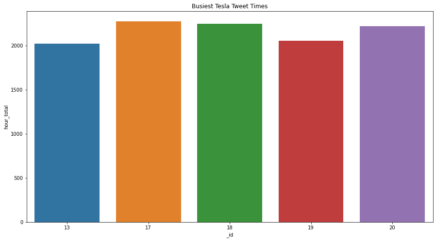

```python
plt.title('Busiest Tesla Tweet Times')
sns.barplot(times_df._id, times_df.hour_total)
```

```python
hourstat = []
for hour in times_df._id:
    if hour ==0 or hour == 1 or hour == 2 or hour == 3 or hour == 4 or hour == 5:
        quarter = 1
        hourstat.append(quarter)
    elif hour ==6 or hour == 7 or hour == 8 or hour == 9 or hour == 10 or hour == 11:
        quarter = 2
        hourstat.append(quarter)
    elif hour ==12 or hour == 13 or hour == 14 or hour == 15 or hour == 16 or hour == 17:
        quarter = 3
        hourstat.append(quarter)
    elif hour == 18  or hour == 19 or hour == 20 or hour == 21 or hour == 22 or hour == 23:
        quarter = 4
        hourstat.append(quarter)
```

```python
hourstat
```

```
[3, 4, 4, 4, 3]
```

## Question 11 : What are the top 5 most used languages among users that have more than 500 followers?

```python
# display most used laguages among users that have more than 500 followers

def topLanguages(n):
    pipeline = [{"$match" : {'user.followers_count' : {"$gte": 500}}},
    {"$group":{"_id": "$lang", 'lang_total' : {"$sum" : 1}}},
    {"$sort": {'lang_total' : -1}},
    {"$limit": 5}]

    result_list = []
    result = db.tesla_tweets.aggregate(pipeline)

    for res in result:
        result_list.append(res)

    return result_list
```

```python
top_languages = topLanguages(5)
lang_df = pd.DataFrame(list(top_languages))
lang_df
new_lang = ['English', 'Spanish', 'Japanese', 'Undetermined', 'German']
lang_df['new_lang'] = new_lang
```

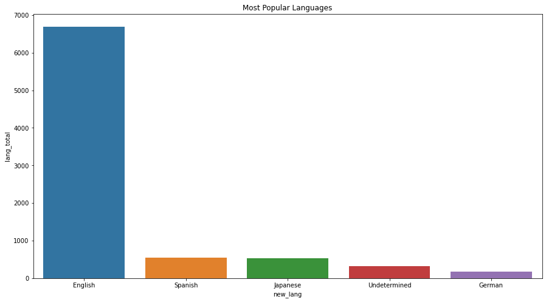

```python
plt.title('Most Popular Languages')
sns.barplot(lang_df.new_lang, lang_df.lang_total)
```